# Analysis on Brazilian elections

### Cook’s dist vs Leverage

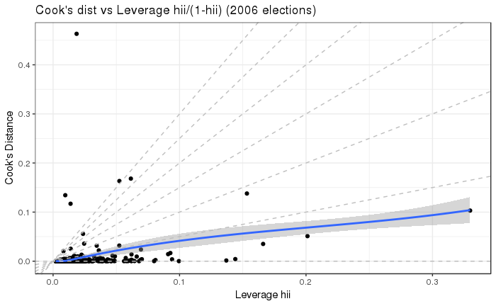

```r
mod_2006 %>%
  ggplot(aes(.hat, .cooksd)) +
  geom_point(na.rm=TRUE) +
  stat_smooth(method="loess", na.rm=TRUE) +
  xlab("Leverage hii")+ylab("Cook's Distance") +
  ggtitle("Cook's dist vs Leverage hii/(1-hii) (2006 elections)") +
  geom_abline(slope=seq(0,3,0.5), color="gray", linetype="dashed")
```

- We can see no outliers that would drastically change the results of our model.

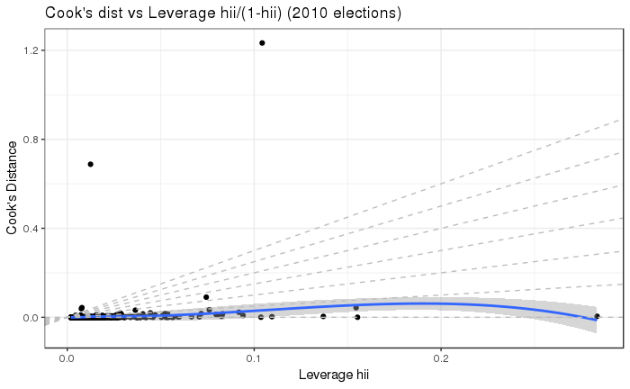

```r
mod_2010 %>%
  ggplot(aes(.hat, .cooksd)) +
  geom_point(na.rm=TRUE) +
  stat_smooth(method="loess", na.rm=TRUE) +
  xlab("Leverage hii")+ylab("Cook's Distance") +
  ggtitle("Cook's dist vs Leverage hii/(1-hii) (2010 elections)") +
  geom_abline(slope=seq(0,3,0.5), color="gray", linetype="dashed")
```

## Cross Validation

### Validate

```r
predictions <- mod_2006 %>% predict(validate_data_2006)
data.frame( R2 = caret::R2(predictions, validate_data_2006$votos),
            RMSE = caret::RMSE(predictions, validate_data_2006$votos),
            MAE = caret::MAE(predictions, validate_data_2006$votos),
            ERR = caret::RMSE(predictions, validate_data_2006$votos)/
              mean(validate_data_2006$votos))
```

| R2 | RMSE | MAE | ERR |
| --- | --- | --- | --- |
| 0.5639769 | 30668.81 | 13639.2 | 1.321718 |

Now let’s talk about the results taken from the validate data for 2006 elections (more meaningful).

- We got a decent 0.56 R² and adjusted R² approximately (notice the decrease). This means that this model explain approximately 56% of the response variable variability.
- The average difference between the observed known outcome values and the values predicted by the model (RMSE) was of approximately 30669.
  - Our model would miss the mark by approximately 30669 (RMSE), that is if candidate had one million votes we would predict 30669 more than we should (or less than we should).
- The average absolute difference between observed and predicted outcomes (MAE) was approximately 13639.2 .
- The prediction error rate (ERR) was 1.321718.

```r
predictions <- mod_2010 %>% predict(validate_data_2010)
data.frame( R2 = caret::R2(predictions, validate_data_2010$votos),
            RMSE = caret::RMSE(predictions, validate_data_2010$votos),
            MAE = caret::MAE(predictions, validate_data_2010$votos),
            ERR = caret::RMSE(predictions, validate_data_2010$votos)/
              mean(validate_data_2010$votos))
```

| R2 | RMSE | MAE | ERR |
| --- | --- | --- | --- |
| 0.6208835 | 27599.68 | 13981.47 | 1.275393 |

Now let’s talk about the results taken from the validate data for 2010 elections (more meaningful).

*The average difference between the observed known outcome values and the values predicted by the model (RMSE) was of approximately 27600 + Our model would miss the mark by approximately 27600 (RMSE), that is if candidate had one million votes we would predict 27600 more than we should (or less than we should).* The average absolute difference between observed and predicted outcomes (MAE) was approximately 13981. * The prediction error rate (ERR) was 1.275393.

> We have signs here of a decent although not brilliant fit of the model for 2006 elections. There’s no clear evidence of overfitting as test, validate and train rendered consonant results.

### Test

```r
predictions <- mod_2006 %>% predict(test_data_2006)
data.frame( R2 = caret::R2(predictions, test_data_2006$votos),
            RMSE = caret::RMSE(predictions, test_data_2006$votos),
            MAE = caret::MAE(predictions, test_data_2006$votos),
            ERR = caret::RMSE(predictions, test_data_2006$votos)/
              mean(test_data_2006$votos))
```

| R2 | RMSE | MAE | ERR |
| --- | --- | --- | --- |
| 0.5810708 | 28937.3 | 13644.98 | 1.236634 |

Now let’s talk about the results taken from the test data for 2006 elections (most meaningful).

- We got a decent 0.58 R² and adjusted R² approximately (notice the decrease). This means that this model explain approximately 58% of the response variable variability. (Smaller than the previous model)
- The average difference between the observed known outcome values and the values predicted by the model (RMSE) was of approximately 28937
  - Our model would miss the mark by approximately 28937 (RMSE), that is if candidate had one million votes we would predict 28937 more than we should (or less than we should).
- The average absolute difference between observed and predicted outcomes (MAE) was approximately 13645.
- The prediction error rate (ERR) was 1.236634.

```r
predictions <- mod_2010 %>% predict(test_data_2010)
data.frame( R2 = caret::R2(predictions, test_data_2010$votos),
            RMSE = caret::RMSE(predictions, test_data_2010$votos),
            MAE = caret::MAE(predictions, test_data_2010$votos),
            ERR = caret::RMSE(predictions, test_data_2010$votos)/
              mean(test_data_2010$votos))
```

| R2 | RMSE | MAE | ERR |
| --- | --- | --- | --- |
| 0.5920504 | 26772.92 | 12847.32 | 1.347477 |

> The model for the 2010 elections also showed of a decent although not brilliant fit. There’s no clear evidence of overfitting as test, validate and train rendered consonant results.

# Removing redundant predictors

##### The quality assesment we performed (residue analysis, cross validation …) suggested that **sqrt.total_receita**, **sqrt.total_despesa** and **log.quantidade_fornecedores** were the most meaningful predictors (those that could explain the votes the most).

##### Evidence suggested that the rest of the predictors, such as **partido**, **uf** and **estado.civil** were redundant. For this reason we’ll try to create a model using only the most meaningful predictors (i.e a *skimmed model*).

## 2006 elections skimmed model

```r
mod_2006 <- lm(votos ~ sqrt.total_receita * sqrt.total_despesa +
                 log.quantidade_fornecedores,
          data = train_data_2006)
broom::glance(mod_2006)
```

|  | r.squared | adj.r.squared | sigma | statistic | p.value | df | logLik | AIC | BIC | deviance | df.residual |
| --- | --- | --- | --- | --- | --- | --- | --- | --- | --- | --- | --- |
| 1 | 0.5178848 | 0.516759 | 31574.54 | 460.0231 | 1.847744e-269 | 5 | -20233.9 | 40479.79 | 40512.48 | 1.707778e+12 | 1713 |

- As the quality metric come from training they aren’t that meaningful
  - A decent $R^2$ and $adjusted \thinspace R^2$ very close to the original model.
  - The $F \thinspace statistic$ (statistic) is way bigger than 1 (a good sign) and bigger than that of the original model.

### Residue Analysis

##### Resorting to thumb rules regarding **Cook’s Distance** we’ll use $D_i > 1$ as a cutoff for highly influential points/outliers

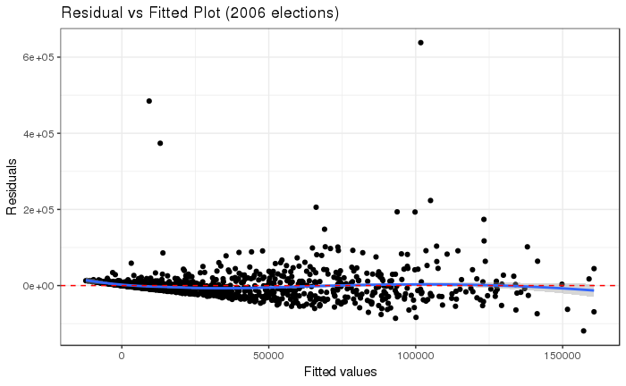

```r
mod_2006 %>%
  ggplot(aes(.fitted, .resid)) +
  geom_point() +
  stat_smooth(method="loess") +
  geom_hline(col="red",
             yintercept=0,
             linetype="dashed") +
  labs(y="Residuals",
       x="Fitted values",
       title="Residual vs Fitted Plot (2006 elections)")
```

- There’s indication, although not strong, of a pattern in the residual vs fitted, this is a bad sign for the analyzed model.
  - Pattern stronger than the one from the original model.

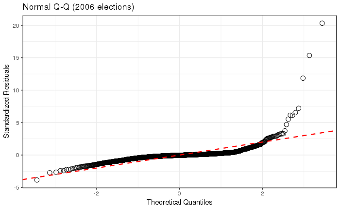

```r
mod_2006 %>%
  ggplot(aes(sample=rstandard(.))) +
  stat_qq(na.rm = TRUE,
          shape=1,size=3) +      # open circles
  labs(title="Normal Q-Q (2006 elections)",        # plot title
  x="Theoretical Quantiles",      # x-axis label
  y="Standardized Residuals") +   # y-axis label +
  geom_abline(color = "red",
              size = 0.8,
              linetype="dashed")  # dashed reference line
```

- Our residuals somewhat deviate from a normal distribution. As we have a relatively mild deviation we have a negative yet mild sign for our model.
  - Results similar to original model.

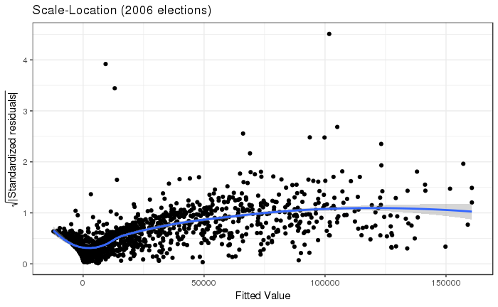

```r
mod_2006 %>%
  ggplot(aes(.fitted,
             sqrt(abs(.stdresid)))) +
  geom_point(na.rm=TRUE) +
  stat_smooth(method="loess",
              na.rm = TRUE) +
  labs(title = "Scale-Location (2006 elections)",
       x= "Fitted Value",
       y = expression(sqrt("|Standardized residuals|")))
```

- The residuals are not equally spread. Our model has violated the assumption of $homoscedasticity$ (equal variance)
  - Violation slightly stronger here.

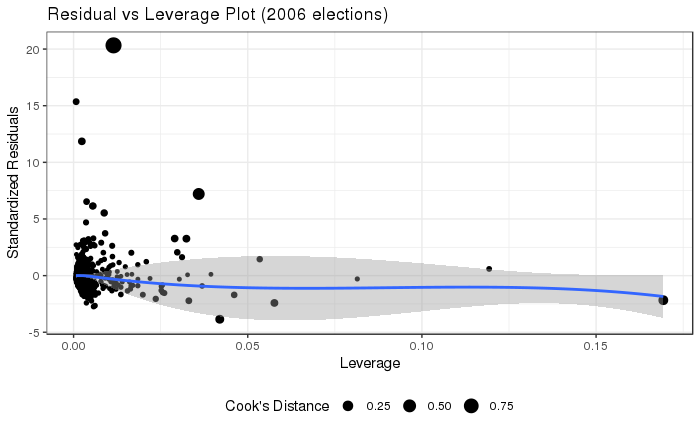

```r
mod_2006 %>%
  ggplot(aes(.hat, .stdresid)) +
  geom_point(aes(size=.cooksd), na.rm=TRUE) +
  stat_smooth(method="loess", na.rm=TRUE) +
  xlab("Leverage")+ylab("Standardized Residuals") +
  ggtitle("Residual vs Leverage Plot (2006 elections)") +
  scale_size_continuous("Cook's Distance", range=c(1,5)) +
  theme(legend.position="bottom")
```

- We can see no outliers that would drastically change the results of our model.

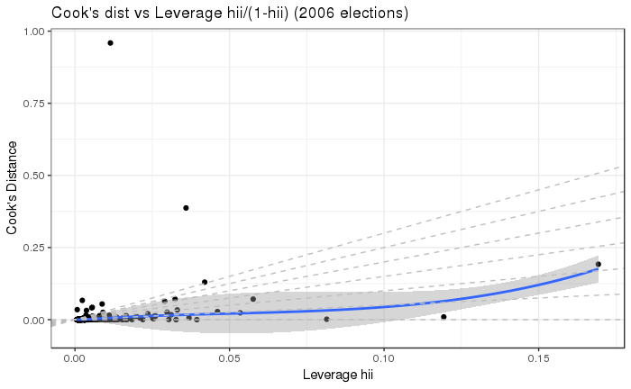

```r
mod_2006 %>%
  ggplot(aes(.hat, .cooksd)) +
  geom_point(na.rm=TRUE) +
  stat_smooth(method="loess", na.rm=TRUE) +
  xlab("Leverage hii")+ylab("Cook's Distance") +
  ggtitle("Cook's dist vs Leverage hii/(1-hii) (2006 elections)") +
  geom_abline(slope=seq(0,3,0.5), color="gray", linetype="dashed")
```

- Here we see indication of a somewhat more influential data point (still within acceptable range).

### Cross Validation

#### Validate

```r
predictions <- mod_2006 %>% predict(validate_data_2006)
data.frame( R2 = caret::R2(predictions, validate_data_2006$votos),
            RMSE = caret::RMSE(predictions, validate_data_2006$votos),
            MAE = caret::MAE(predictions, validate_data_2006$votos),
            ERR = caret::RMSE(predictions, validate_data_2006$votos)/
              mean(validate_data_2006$votos))
```

| R2 | RMSE | MAE | ERR |
| --- | --- | --- | --- |
| 0.5632688 | 30697.33 | 13569.11 | 1.322946 |

Now let’s talk about the results taken from the validate data (more meaningful).

- We got a decent 0.56 R² and adjusted R² approximately. This means that this model explain approximately 56% of the response variable variability.
- The average difference between the observed known outcome values and the values predicted by the model (RMSE) was of approximately 30697.
  - Our model would miss the mark by approximately 30697 (RMSE), that is if candidate had one million votes we would predict 30697 more than we should (or less than we should).
- The average absolute difference between observed and predicted outcomes (MAE) was approximately 13569.
- The prediction error rate (ERR) was 1.322946.

#### Test

```r
predictions <- mod_2006 %>% predict(test_data_2006)
data.frame( R2 = caret::R2(predictions, test_data_2006$votos),
            RMSE = caret::RMSE(predictions, test_data_2006$votos),
            MAE = caret::MAE(predictions, test_data_2006$votos),
            ERR = caret::RMSE(predictions, test_data_2006$votos)/
              mean(test_data_2006$votos))
```

| R2 | RMSE | MAE | ERR |
| --- | --- | --- | --- |
| 0.5882667 | 28684.37 | 13522.92 | 1.225825 |

Now let’s talk about the results taken from the test data (most meaningful).

- We got a decent 0.59 R² and adjusted R² approximately. This means that this model explain approximately 59% of the response variable variability.
- The average difference between the observed known outcome values and the values predicted by the model (RMSE) was of approximately 28684.
  - Our model would miss the mark by approximately 28684 (RMSE), that is if candidate had one million votes we would predict 28684 more than we should (or less than we should).
- The average absolute difference between observed and predicted outcomes (MAE) was approximately 13522.92.
- The prediction error rate (ERR) was 1.225825.

> Our skimmed model fared quite similarly to the original model especially in the cross validation.

## 2010 elections skimmed model

```r
mod_2010 <- lm(votos ~ sqrt.total_receita * sqrt.total_despesa,
          data = train_data_2010)
broom::glance(mod_2010)
```

|  | r.squared | adj.r.squared | sigma | statistic | p.value | df | logLik | AIC | BIC | deviance | df.residual |
| --- | --- | --- | --- | --- | --- | --- | --- | --- | --- | --- | --- |
| 1 | 0.4333085 | 0.4324653 | 41756.64 | 513.8305 | 5.577796e-248 | 4 | -24356.27 | 48722.55 | 48750.6 | 3.515132e+12 | 2016 |

- As the quality metric come from training they aren’t that meaningful
  - The $R^2$ and $adjusted \thinspace R^2$ around $0.43$ are borderline disappointing and close to the original model.
  - The $F \thinspace statistic$ (statistic) is way bigger than 1 (a good sign) and bigger than the one from the original model.

### Residue Analysis

##### Resorting to thumb rules regarding **Cook’s Distance** we’ll use $D_i > 1$ as a cutoff for highly influential points/outliers

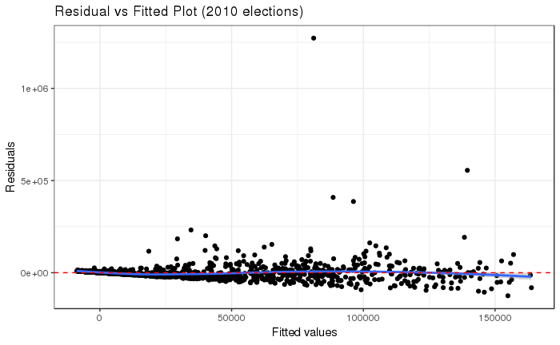

```r
mod_2010 %>%
  ggplot(aes(.fitted, .resid)) +
  geom_point() +
  stat_smooth(method="loess") +
  geom_hline(col="red",
             yintercept=0,
             linetype="dashed") +
  labs(y="Residuals",
       x="Fitted values",
       title="Residual vs Fitted Plot (2010 elections)")
```

- Here we can see rather equally spread (could be better) residuals around a horizontal line without distinct patterns. A good sign for the model.
  - Results slightly to those of the original model.

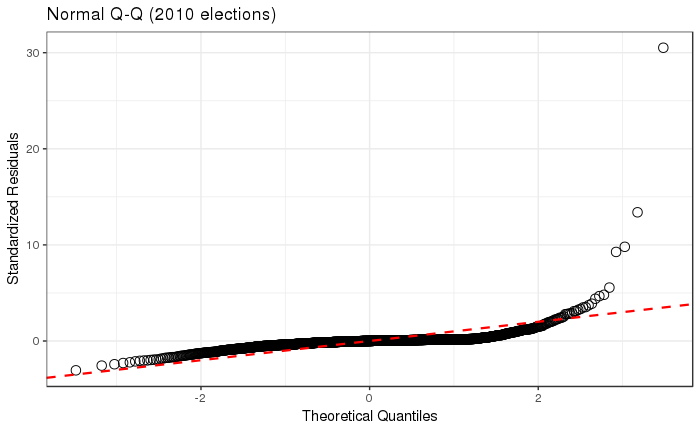

```r
mod_2010 %>%
  ggplot(aes(sample=rstandard(.))) +
  stat_qq(na.rm = TRUE,
          shape=1,size=3) +      # open circles
  labs(title="Normal Q-Q (2010 elections)",        # plot title
  x="Theoretical Quantiles",      # x-axis label
  y="Standardized Residuals") +   # y-axis label +
  geom_abline(color = "red",
              size = 0.8,
              linetype="dashed")  # dashed reference line
```

- Although not perfect we can see that the residuals for this model are closer to normally distributed.
  - Results similar to those from the original model.

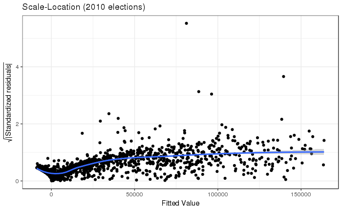

```r
mod_2010 %>%
  ggplot(aes(.fitted,
             sqrt(abs(.stdresid)))) +
  geom_point(na.rm=TRUE) +
  stat_smooth(method="loess",
              na.rm = TRUE) +
  labs(title = "Scale-Location (2010 elections)",
       x= "Fitted Value",
       y = expression(sqrt("|Standardized residuals|")))
```

- Here we see a scenario similar to the one we just witnessed, but in the case of this model the residuals are closer to equally spread.
  - Results somewhat better than ones from original model.

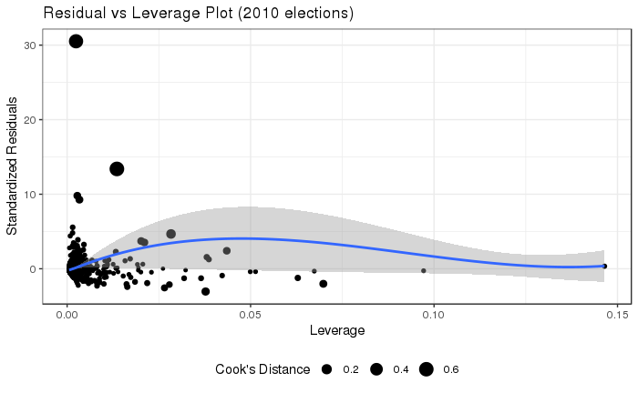

```r
mod_2010 %>%
  ggplot(aes(.hat, .stdresid)) +
  geom_point(aes(size=.cooksd), na.rm=TRUE) +
  stat_smooth(method="loess", na.rm=TRUE) +
  xlab("Leverage")+ylab("Standardized Residuals") +
  ggtitle("Residual vs Leverage Plot (2010 elections)") +
  scale_size_continuous("Cook's Distance", range=c(1,5)) +
  theme(legend.position="bottom")
```

- We can see no outliers that would drastically change the results of our model.

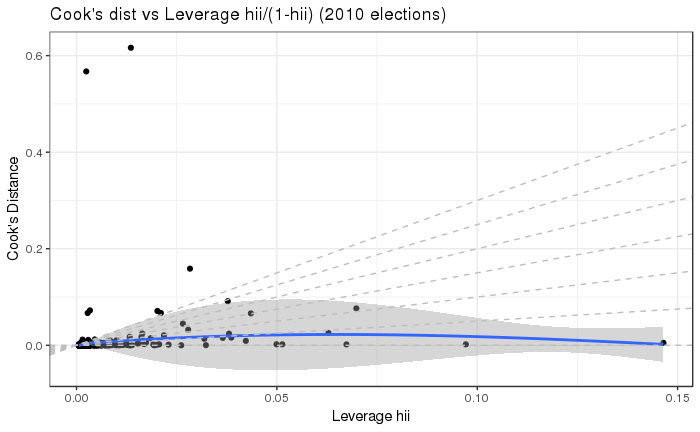

```r
mod_2010 %>%
  ggplot(aes(.hat, .cooksd)) +
  geom_point(na.rm=TRUE) +
  stat_smooth(method="loess", na.rm=TRUE) +
  xlab("Leverage hii")+ylab("Cook's Distance") +
  ggtitle("Cook's dist vs Leverage hii/(1-hii) (2010 elections)") +
  geom_abline(slope=seq(0,3,0.5), color="gray", linetype="dashed")
```

- We can see no outliers that would drastically change the results of our model.

### Cross Validation

```r
predictions <- mod_2010 %>% predict(validate_data_2010)
data.frame( R2 = caret::R2(predictions, validate_data_2010$votos),
            RMSE = caret::RMSE(predictions, validate_data_2010$votos),
            MAE = caret::MAE(predictions, validate_data_2010$votos),
            ERR = caret::RMSE(predictions, validate_data_2010$votos)/
              mean(validate_data_2010$votos))
```

| R2 | RMSE | MAE | ERR |
| --- | --- | --- | --- |
| 0.6298557 | 27228.86 | 14152.26 | 1.258257 |

Now let’s talk about the results taken from the validate data (more meaningful).

- We got a decent 0.63 R² and adjusted R² approximately. This means that this model explain approximately 63% of the response variable variability.
- The average difference between the observed known outcome values and the values predicted by the model (RMSE) was of approximately 27229.
  - Our model would miss the mark by approximately 27229 (RMSE), that is if candidate had one million votes we would predict 27229 more than we should (or less than we should).
- The average absolute difference between observed and predicted outcomes (MAE) was approximately 14152.26.
- The prediction error rate (ERR) was 1.258257.

```r
predictions <- mod_2010 %>% predict(test_data_2010)
data.frame( R2 = caret::R2(predictions, test_data_2010$votos),
            RMSE = caret::RMSE(predictions, test_data_2010$votos),
            MAE = caret::MAE(predictions, test_data_2010$votos),
            ERR = caret::RMSE(predictions, test_data_2010$votos)/
              mean(test_data_2010$votos))
```

| R2 | RMSE | MAE | ERR |
| --- | --- | --- | --- |
| 0.6008068 | 26425.65 | 13160.91 | 1.329999 |

Now let’s talk about the results taken from the test data (most meaningful).

- We got a decent 0.60 R² and adjusted R² approximately (notice the decrease). This means that this model explain approximately 60% of the response variable variability.
- The average difference between the observed known outcome values and the values predicted by the model (RMSE) was of approximately 26426.
  - Our model would miss the mark by approximately 26426 (RMSE), that is if candidate had one million votes we would predict 26426 more than we should (or less than we should).
- The average absolute difference between observed and predicted outcomes (MAE) was approximately 13160.91.
- The prediction error rate (ERR) was 1.329999.

> The skimmed model fared quite similarly to the original model in terms of cross validation. Furthermore, we got rid of the overly influential outlier.

# Model for both elections

## Split data for cross validation

- Let’s use the $50/25/25$ proportions for the train,validate and test datasets

```r
set.seed(11) # We set the set for reason of reproducibility
scaled_data %>%
  dplyr::sample_frac(.5) -> train_data
encoding <- build_encoding(dataSet = train_data,
                           cols = c("uf","sexo","grau",
                                    "partido","estado_civil"),
                           verbose = F)
train_data <- one_hot_encoder(dataSet = train_data,
                           encoding = encoding,
                           drop = TRUE,
                           verbose = F)
cat("#### Train Data ",
    "\n##### Observations: ",nrow(train_data),
    "\n##### Variables: ",ncol(train_data))
```

#### Train Data

##### Observations: 3738

##### Variables: 105

```r
set.seed(11) # We set the set for reason of reproducibility
dplyr::anti_join(scaled_data,
                 train_data,
                 by = 'id') -> intermediate_data
intermediate_data %>%
  dplyr::sample_frac(.5) -> test_data
test_data <- one_hot_encoder(dataSet = test_data,
                           encoding = encoding,
                           drop = TRUE,
                           verbose = F)
cat("#### Test Data ",
    "\n##### Observations: ",nrow(test_data),
    "\n##### Variables: ",ncol(test_data))
```

#### Test Data

##### Observations: 1869

##### Variables: 105

```r
set.seed(11) # We set the set for reason of reproducibility
dplyr::anti_join(intermediate_data,
                 test_data,
                 by = 'id') -> validate_data
validate_data <- one_hot_encoder(dataSet = validate_data,
                           encoding = encoding,
                           drop = TRUE,
                           verbose = F)
rm(intermediate_data)
cat("#### Validate Data ",
    "\n##### Observations: ",nrow(validate_data),
    "\n##### Variables: ",ncol(validate_data))
```

#### Validate Data

##### Observations: 1869

##### Variables: 105

```r
mod <- lm(votos ~ sqrt.total_receita * sqrt.total_despesa +
                  log.quantidade_fornecedores,
          data = train_data)
broom::glance(mod)
```

|  | r.squared | adj.r.squared | sigma | statistic | p.value | df | logLik | AIC | BIC | deviance | df.residual |
| --- | --- | --- | --- | --- | --- | --- | --- | --- | --- | --- | --- |
| 1 | 0.5174964 | 0.5169794 | 32531.6 | 1000.932 | 0 | 5 | -44139.19 | 88290.38 | 88327.73 | 3.950653e+12 | 3733 |

- As the quality metric come from training they aren’t that meaningful
  - The $R^2$ and $adjusted \thinspace R^2$ are decent.
  - The $F \thinspace statistic$ (statistic) is way bigger than 1 (a good sign).

## Residue Analysis

##### Resorting to thumb rules regarding **Cook’s Distance** we’ll use $D_i > 1$ as a cutoff for highly influential points/outliers

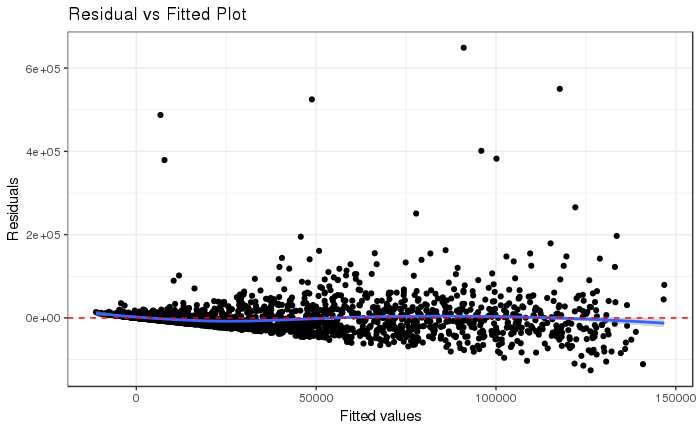

```r
mod %>%
  ggplot(aes(.fitted, .resid)) +
  geom_point() +
  stat_smooth(method="loess") +
  geom_hline(col="red",
             yintercept=0,
             linetype="dashed") +
  labs(y="Residuals",
       x="Fitted values",
       title="Residual vs Fitted Plot")
```

- There’s mild indication of a pattern in the residual, this is a bad sign for the analyzed model.

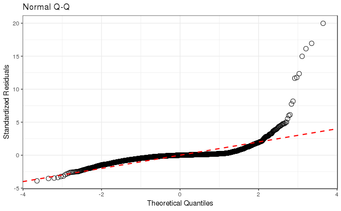

```r
mod %>%
  ggplot(aes(sample=rstandard(.))) +
  stat_qq(na.rm = TRUE,
          shape=1,size=3) +      # open circles
  labs(title="Normal Q-Q",        # plot title
  x="Theoretical Quantiles",      # x-axis label
  y="Standardized Residuals") +   # y-axis label +
  geom_abline(color = "red",
              size = 0.8,
              linetype="dashed")  # dashed reference line
```

- Our residuals deviate considerably from a normal distribution.

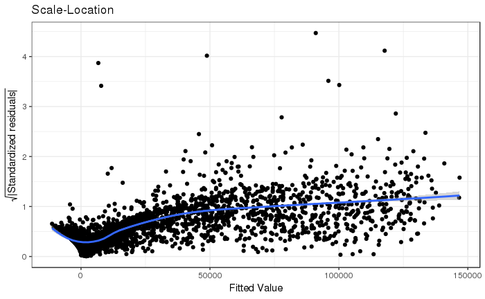

```r
mod %>%
  ggplot(aes(.fitted,
             sqrt(abs(.stdresid)))) +
  geom_point(na.rm=TRUE) +
  stat_smooth(method="loess",
              na.rm = TRUE) +
  labs(title = "Scale-Location",
       x= "Fitted Value",
       y = expression(sqrt("|Standardized residuals|")))
```

- The residuals are not equally spread. Our model has violated the assumption of $homoscedasticity$ (equal variance).

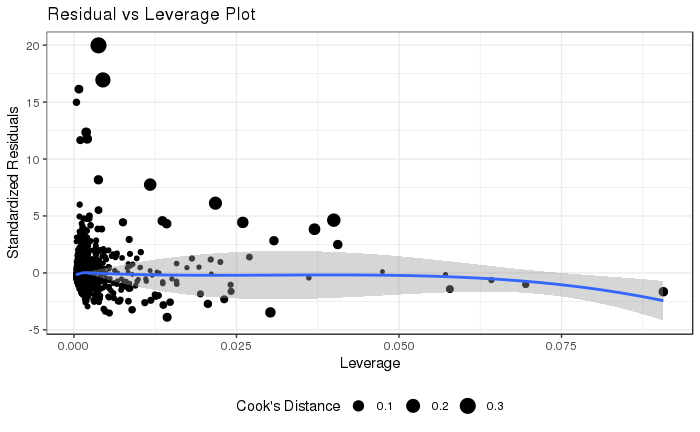

```r
mod %>%
  ggplot(aes(.hat, .stdresid)) +
  geom_point(aes(size=.cooksd), na.rm=TRUE) +
  stat_smooth(method="loess", na.rm=TRUE) +
  xlab("Leverage")+ylab("Standardized Residuals") +
  ggtitle("Residual vs Leverage Plot") +
  scale_size_continuous("Cook's Distance", range=c(1,5)) +
  theme(legend.position="bottom")
```

- We can see no outliers that would drastically change the results of our model.

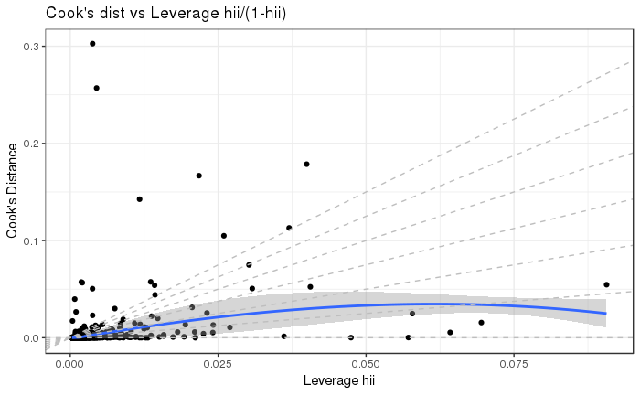

```r
mod %>%
  ggplot(aes(.hat, .cooksd)) +
  geom_point(na.rm=TRUE) +
  stat_smooth(method="loess", na.rm=TRUE) +
  xlab("Leverage hii")+ylab("Cook's Distance") +
  ggtitle("Cook's dist vs Leverage hii/(1-hii)") +
  geom_abline(slope=seq(0,3,0.5), color="gray", linetype="dashed")
```

- We can see no outliers that would drastically change the results of our model.

## Cross Validation

```r
predictions <- mod %>% predict(validate_data)
data.frame( R2 = caret::R2(predictions, validate_data$votos),
            RMSE = caret::RMSE(predictions, validate_data$votos),
            MAE = caret::MAE(predictions, validate_data$votos),
            ERR = caret::RMSE(predictions, validate_data$votos)/
              mean(validate_data$votos))
```

| R2 | RMSE | MAE | ERR |
| --- | --- | --- | --- |
| 0.6350622 | 25160.61 | 13125.83 | 1.139725 |

Now let’s talk about the results taken from the validate data (more meaningful).

- We got a decent 0.64 R² and adjusted R² approximately. This means that this model explain approximately 64% of the response variable variability.
- The average difference between the observed known outcome values and the values predicted by the model (RMSE) was of approximately 25161.
  - Our model would miss the mark by approximately 25161 (RMSE), that is if candidate had one million votes we would predict 25161 more than we should (or less than we should).
- The average absolute difference between observed and predicted outcomes (MAE) was approximately 13125.83.
- The prediction error rate (ERR) was 1.139725.

```r
predictions <- mod %>% predict(test_data)
data.frame( R2 = caret::R2(predictions, test_data$votos),
            RMSE = caret::RMSE(predictions, test_data$votos),
            MAE = caret::MAE(predictions, test_data$votos),
            ERR = caret::RMSE(predictions, test_data$votos)/
              mean(test_data$votos))
```

| R2 | RMSE | MAE | ERR |
| --- | --- | --- | --- |
| 0.4187352 | 41802.93 | 14063.7 | 1.855572 |